# Prob_RWD_Rand_block

Table 6.7: Duration Diff Prior P-Values for effect of Probability

|  | P-Value |
| --- | --- |
| T-test | 9.160e-01 |
| T-Test Prior==1 | 8.336e-01 |
| T-Test Prior==0 | 9.474e-01 |

To further examine this effect of prior reward on Movement Duration, the change in Movement Duration was determined from trial to trial. In the above graph Delta Movement Duration is the difference in Movement Duration of the current trial minus the previous trial (PV_(trial=n)-PV_(trial=n-1)). There WAS NOT a statistical difference between trials following and not following reward (paired t-test of subject averages, p = 9.160e-01). Movement Duration WAS NOT significantly different following reward (t-test of subject averages vs a mean of 0, p = 8.336e-01) and Movement Duration DID NOT significantly different following trials where they were not rewarded (t-test of subject averages vs a mean of 0, p = 9.474e-01).

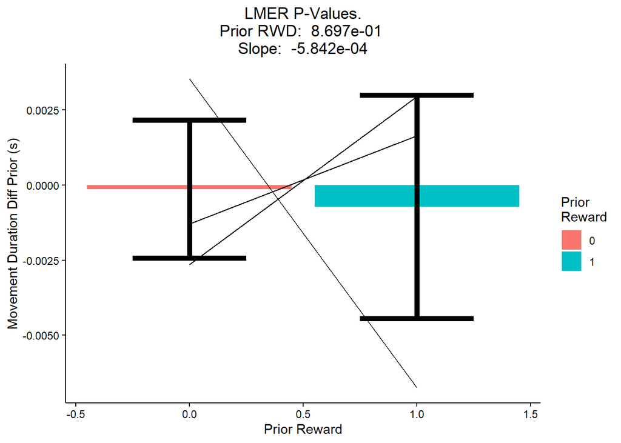

### 6.3.2 Interaction of Prior Reward and Change in Probability of Reward

Table 6.8: Duration Diff Prior P-Values for effect of Diff Probability

|  | P-Value | Slope |
| --- | --- | --- |
| Intercept | 5.647e-01 | 4.300e-03 ± 7.466e-03 |
| Prob Metric | 2.581e-01 | -1.581e-02 ± 1.398e-02 |
| Prior RWD | 3.305e-01 | -1.033e-02 ± 1.062e-02 |
| Interaction | 8.820e-01 | -2.960e-03 ± 1.993e-02 |
| Lm Prior == 1 Prob Effect | 1.929e-01 | -1.877e-02 ± 1.441e-02 |
| LM Prior == 0 Prob Effect | 2.513e-01 | -1.581e-02 ± 1.378e-02 |

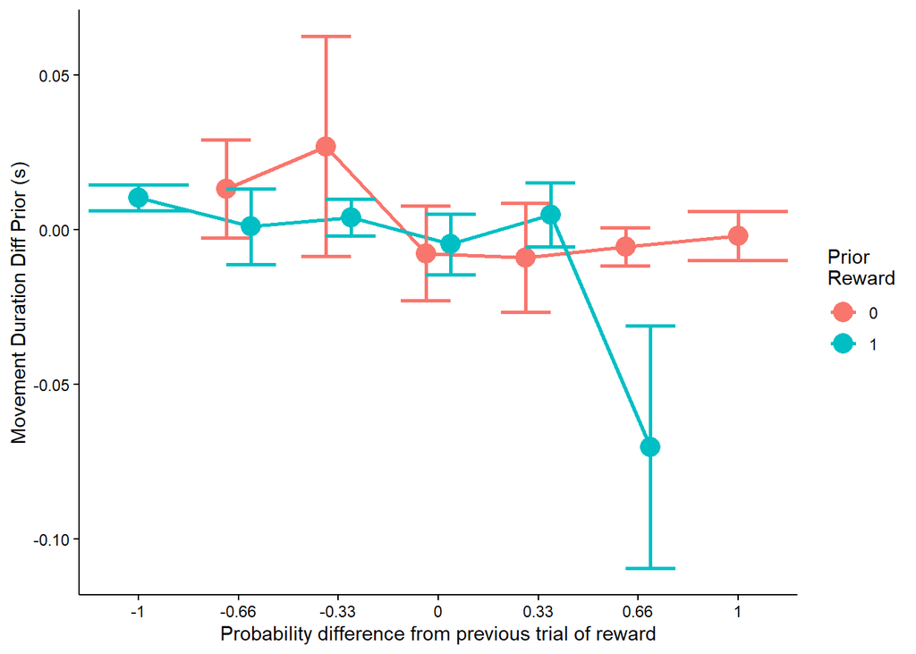

## 6.4 RPE

The linear model used to predict the effect of RPE and prior reward is:

$$Outcome \sim Probability + Prior Reward + Probability*Prior Reward + (1|Subject)$$

In an interacation LMER of RPE and prior reward with subject as a random intercept effect, Movement Duration WAS NOT affected by RPE (p = 2.161e-01) and WAS NOT affected by prior reward (p = 1.724e-01). An interaction of the two factors DID NOT affect Movement Duration (p = 7.045e-01)

Dividing the data set into two groups (trials following reward and trials not following reward) resulted in finding NO significant slope of RPE (p = 8.184e-02) in trials that follow reward, but finding NO significant slope (p = 2.096e-01) in trials that do not follow reward.

Table 6.9: Movement Duration P-Values for effect of RPE

|  | P-Value | Slope |
| --- | --- | --- |
| Intercept | 4.028e-01 | -7.085e-03 ± 8.468e-03 |
| Prob Metric | 2.161e-01 | -3.195e-02 ± 2.583e-02 |
| Prior RWD | 1.724e-01 | 1.645e-02 ± 1.206e-02 |
| Interaction | 7.045e-01 | -1.389e-02 ± 3.663e-02 |
| Lm Prior == 1 Prob Effect | 8.184e-02 | -4.584e-02 ± 2.634e-02 |
| LM Prior == 0 Prob Effect | 2.096e-01 | -3.195e-02 ± 2.547e-02 |

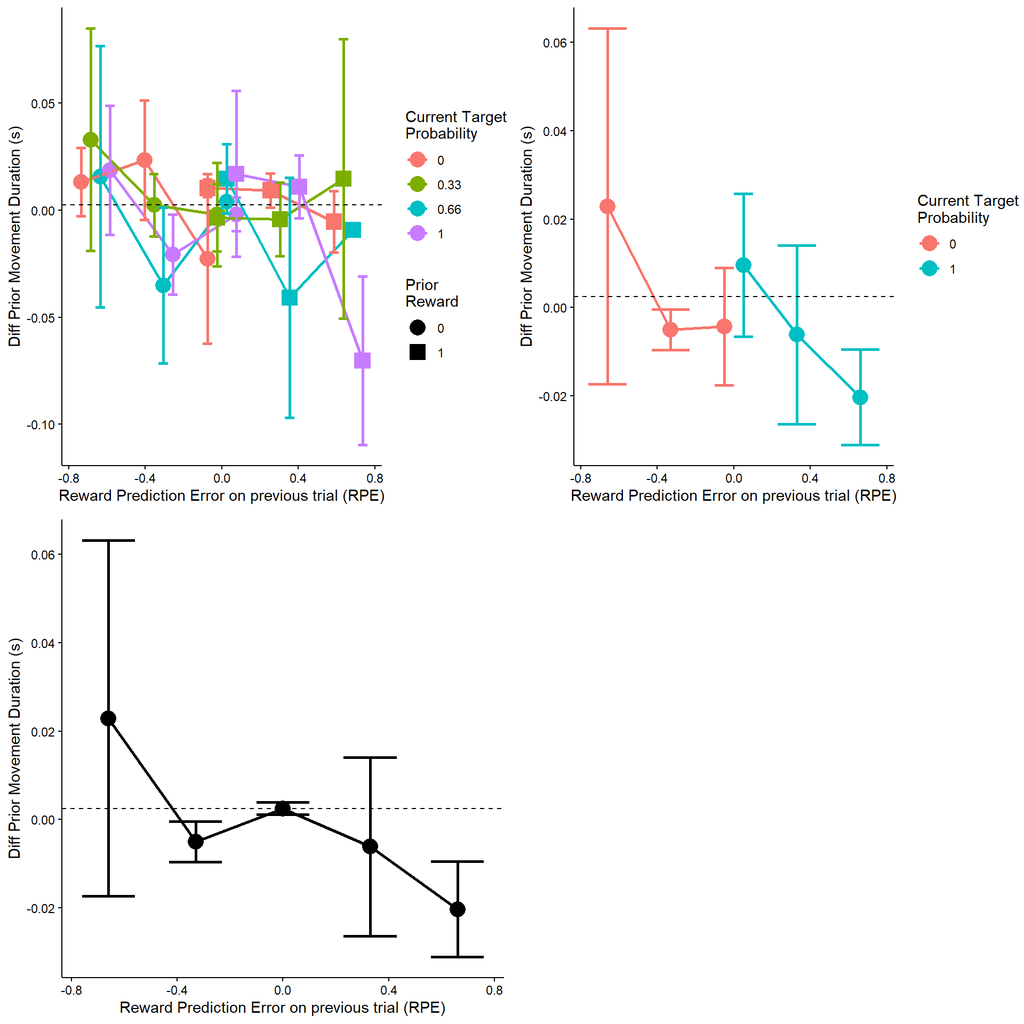

#### 6.4.0.1 T-Tests

Table 6.10: Paired t-test post hoc comparisons with Holm-Bonferonni correction for Movement Duration Diff Prior (m/s).

|  | -1/3 | 0 | 1/3 | 2/3 |
| --- | --- | --- | --- | --- |
| -2/3 | 1 | 1 | 1 | 1 |
| -1/3 | NA | 1 | 1 | 1 |
| 0 | NA | NA | 1 | 0.967 |
| 1/3 | NA | NA | NA | 1 |

These are the uncorrected paired t-test values

Table 6.11: Paired t-test, no correction, for Movement Duration Diff Prior (m/s).

|  | -1/3 | 0 | 1/3 | 2/3 |
| --- | --- | --- | --- | --- |
| -2/3 | 0.525 | 0.59 | 0.616 | 0.262 |
| -1/3 | NA | 0.253 | 0.937 | 0.33 |
| 0 | NA | NA | 0.668 | 0.0967 |
| 1/3 | NA | NA | NA | 0.611 |

#### 6.4.0.2 Summary Table RPE

Table 6.12: Summary data table for Diff Prior Movement Duration. Each row is a probability metric. This is compute subject average for each probability, then average the average. Data is shown as mean ± standard error (lower bound, upper bound) for the 95% confidence interval of that mean.

|  | Mean ± SE (lb, ub) |
| --- | --- |
| -0.66 | 0.0229 ± 0.0132 (-0.00301, 0.0488) |
| -0.33 | -0.00503 ± -0.0029 (0.000662, -0.0107) |
| 0 | 0.0025 ± 0.00145 (-0.00033, 0.00534) |
| 0.33 | -0.00618 ± -0.00357 (0.000813, -0.0132) |
| 0.66 | -0.0203 ± -0.0117 (0.00267, -0.0433) |

# 7 Total Duration

Total time we define as reaction time plus movement time.

## 7.1 Effect of Probability

```
## boundary (singular) fit: see ?isSingular
## boundary (singular) fit: see ?isSingular
```

Total Duration WAS NOT significantly affected by probability of reward (p = 7.342e-01, slope = -3.004e-03). This was tested with an LMER with main outcome of probability and random effect of subject.

The equation below shows the linear model used:
$$Outcome \sim Probability + (1|Subject)$$

Table 7.1: Total Duration P-Values for effect of Probability

|  | P-Value | Slope | Intercept |
| --- | --- | --- | --- |
| All Target LMER | 7.342e-01 | -3.004e-03 ± 8.848e-03 | 6.352e-01 |
| Target 1/4 LMER | 8.567e-01 | -1.539e-03 ± 8.523e-03 | 6.338e-01 |
| Target 1/4 ANOVA | 9.894e-01 | F val: 2.003e-04 |  |

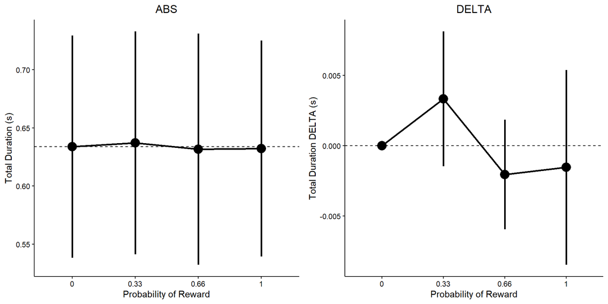

Table 7.2: Paired t-test post hoc comparisons with Holm-Bonferonni correction for Total Duration.

|  | 1/3 | 2/3 | 1 |
| --- | --- | --- | --- |
| 0 | 1 | 1 | 1 |
| 1/3 | NA | 1 | 1 |
| 2/3 | NA | NA | 1 |

These are the uncorrected paired t-test values

Table 7.3: Paired t-test, no correction, for Total Duration.

|  | 1/3 | 2/3 | 1 |
| --- | --- | --- | --- |
| 0 | 0.484 | 0.586 | 0.811 |
| 1/3 | NA | 0.368 | 0.222 |
| 2/3 | NA | NA | 0.95 |

#### 7.1.0.1 Summary Tables

Table 7.4: Summary data table for Total Duration. Each row is a probability metric. This is compute subject average for each probability, then average the average. Data is shown as mean ± standard error (lower bound, upper bound) for the 95% confidence interval of that mean.

|  | Mean ± SE (lb, ub) |
| --- | --- |
| 0 | 0.634 ± 0.366 (-0.0834, 1.35) |
| 0.33 | 0.637 ± 0.368 (-0.0838, 1.36) |
| 0.66 | 0.632 ± 0.365 (-0.0831, 1.35) |
| 1 | 0.632 ± 0.365 (-0.0832, 1.35) |

#### 7.1.0.2 Comparison of 0% and 100% Reward

In a paired t test of subject averages, there WAS NOT a significant difference between 0% and 100% reward conditions for Total Duration (p = 8.112e-01). .

In a ANOVA test of subject averages, there WAS NOT a significant difference between 0% and 100% reward conditions for Total Duration (p = 9.894e-01). .

## 7.2 Effect of Trial

Over the course of the experiment, Total Duration DECREASED with each subsequent trial. This was tested using an LMER of the form: Total Duration = B*Trial + (1|Subject). We found B = -1.811e-04 and a p-value = 0.000e+00, and an intercept of 7.019e-01

The linear model used to predict effect of trial is shown below:
$$Outcome \sim B*Trial + (1|Subject)$$

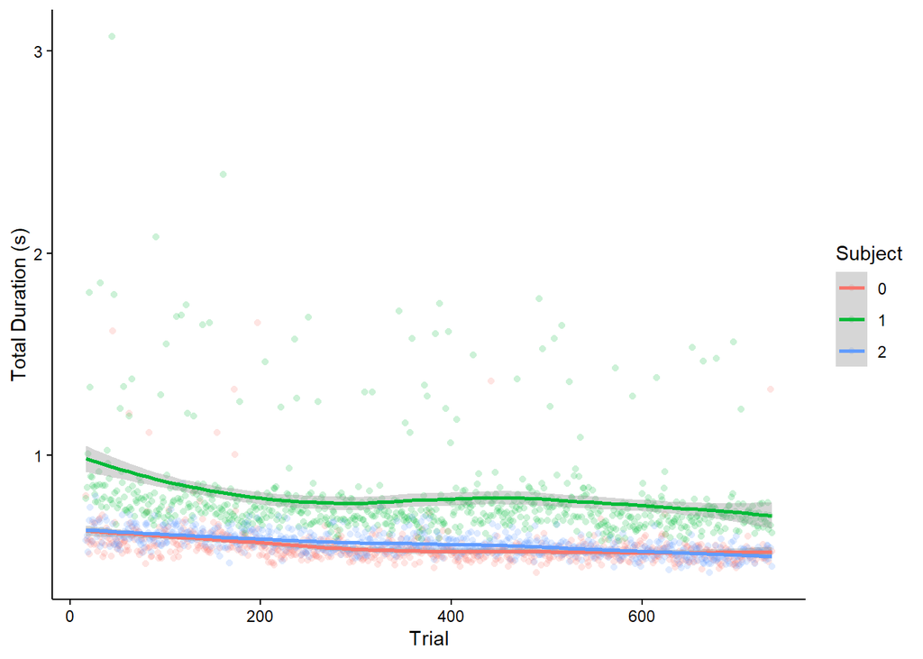

## 7.3 Total Time Following Reward

Using a paried t test, across subjects, the Total Duration in trials following rewarded trials WAS NOT statistically different than trials following nonrewarded tirlas (p = 2.266e-01)

Using an ANOVA test, across subjects, the Total Duration in trials following rewarded trials WAS NOT statistically different than trials following nonrewarded tirlas (p = 9.761e-01)

Table 7.5: Total Duration P-Values for effect of Probability

|  | P-Value |
| --- | --- |
| T-test | 2.266e-01 |
| T-Test Prior==1 | 1.517e-02 |
| T-Test Prior==0 | 1.465e-02 |

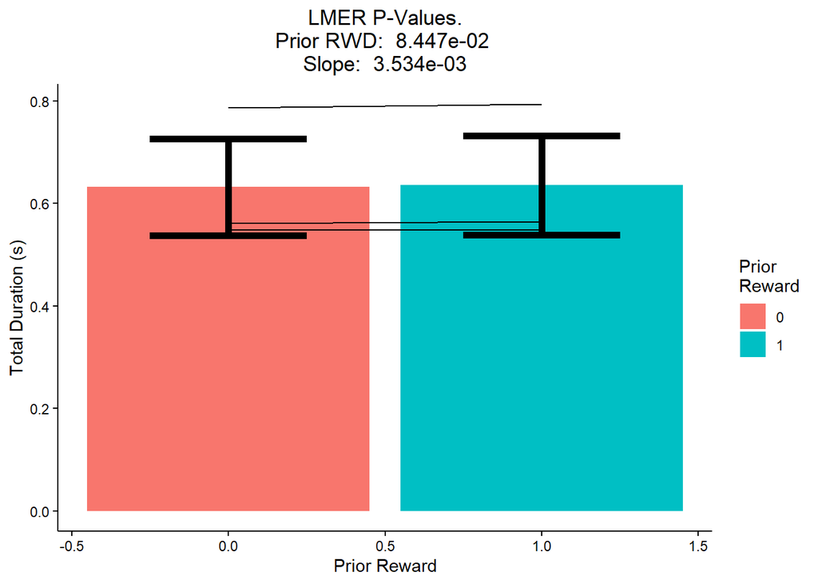

[output not shown]

In an interacation LMER of probability of reward and prior reward with subject as a random intercept effect, Total Duration WAS NOT affected by probability of reward (p = 1.908e-01) and WAS NOT affected by prior reward (p = 3.679e-01). An interaction of the two factors DID NOT affect Total Duration (p = 1.281e-01)

Dividing the data set into two groups (trials following reward and trials not following reward) resulted in finding NO significant slope of probability (p = 3.857e-01) in trials that follow reward, but finding NO significant slope (p = 2.025e-01) in trials that do not follow reward.

The linear model used to predict the effect of probability and prior reward is:

$$Outcome \sim Probability + Prior Reward + Probability*Prior Reward + (1|Subject)$$

|  | P-Value | Slope |
| --- | --- | --- |
| Intercept | 4.441e-16 | 6.402e-01 ± 7.863e-02 |
| Prob Metric | 1.908e-01 | -1.634e-02 ± 1.249e-02 |
| Prior RWD | 3.679e-01 | -9.903e-03 ± 1.100e-02 |
| Interaction | 1.281e-01 | 2.694e-02 ± 1.770e-02 |
| Lm Prior == 1 Prob Effect | 3.857e-01 | 1.061e-02 ± 1.223e-02 |
| LM Prior == 0 Prob Effect | 2.025e-01 | -1.631e-02 ± 1.280e-02 |

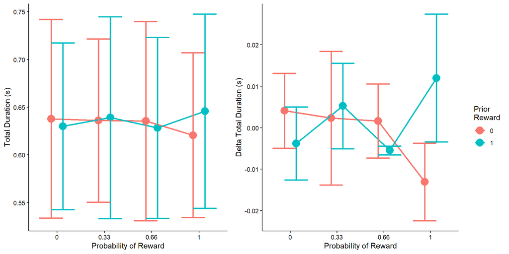

Table 7.7: TotalDur Diff Prior P-Values for effect of Probability

|  | P-Value |
| --- | --- |
| T-test | 5.613e-01 |
| T-Test Prior==1 | 8.752e-01 |
| T-Test Prior==0 | 2.597e-01 |

To further examine this effect of prior reward on Total Duration, the change in Total Duration was determined from trial to trial. In the above graph Delta Total Duration is the difference in Total Duration of the current trial minus the previous trial (PV_(trial=n)-PV_(trial=n-1)). There WAS NOT a statistical difference between trials following and not following reward (paired t-test of subject averages, p = 5.613e-01). Total Duration WAS NOT significantly different following reward (t-test of subject averages vs a mean of 0, p = 8.752e-01) and Total Duration DID NOT significantly different following trials where they were not rewarded (t-test of subject averages vs a mean of 0, p = 2.597e-01).

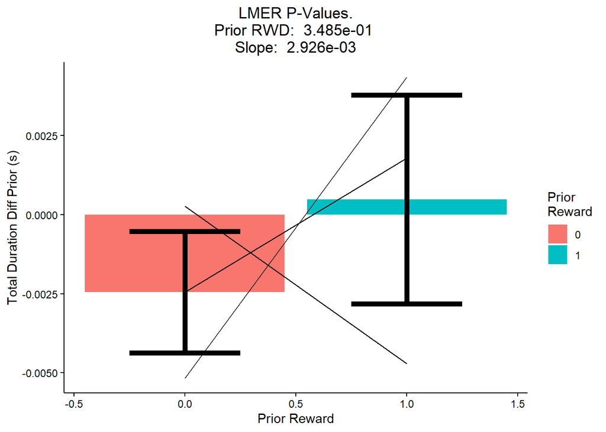

### 7.3.2 Interaction of Prior Reward and Change in Probability of Reward

Table 7.8: TotalDur Diff Prior P-Values for effect of Diff Probability

|  | P-Value | Slope |
| --- | --- | --- |
| Intercept | 6.868e-01 | 2.974e-03 ± 7.376e-03 |
| Prob Metric | 1.623e-01 | -1.930e-02 ± 1.381e-02 |
| Prior RWD | 4.914e-01 | -7.216e-03 ± 1.049e-02 |
| Interaction | 8.949e-01 | 2.602e-03 ± 1.969e-02 |
| Lm Prior == 1 Prob Effect | 2.420e-01 | -1.669e-02 ± 1.427e-02 |
| LM Prior == 0 Prob Effect | 1.555e-01 | -1.930e-02 ± 1.359e-02 |

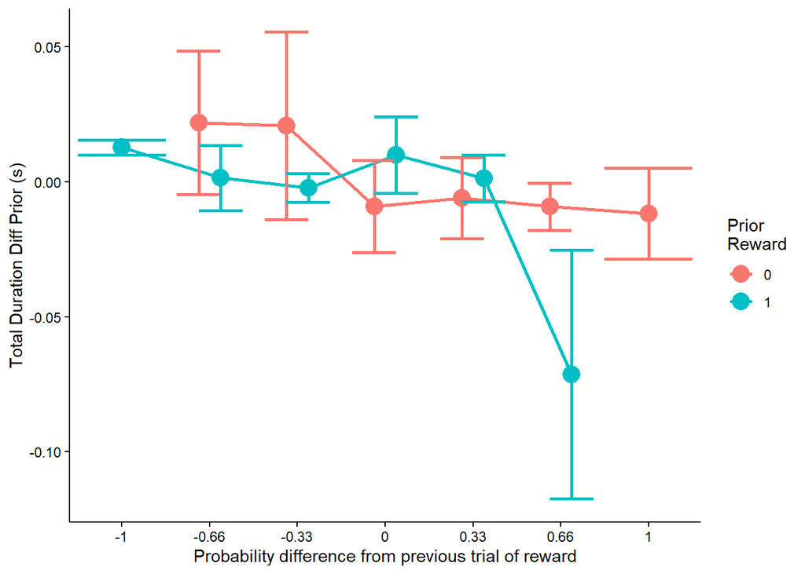

## 7.4 RPE

The linear model used to predict the effect of RPE and prior reward is:

$$Outcome \sim Probability + Prior Reward + Probability*Prior Reward + (1|Subject)$$

In an interacation LMER of RPE and prior reward with subject as a random intercept effect, Total Duration WAS NOT affected by RPE (p = 7.989e-02) and WAS NOT affected by prior reward (p = 6.147e-02). An interaction of the two factors DID NOT affect Total Duration (p = 9.799e-01)

Dividing the data set into two groups (trials following reward and trials not following reward) resulted in finding NO significant slope of RPE (p = 9.328e-02) in trials that follow reward, but finding NO significant slope (p = 7.506e-02) in trials that do not follow reward.

Table 7.9: Total Duration P-Values for effect of RPE

|  | P-Value | Slope |
| --- | --- | --- |
| Intercept | 1.461e-01 | -1.216e-02 ± 8.364e-03 |
| Prob Metric | 7.989e-02 | -4.468e-02 ± 2.551e-02 |
| Prior RWD | 6.147e-02 | 2.227e-02 ± 1.191e-02 |
| Interaction | 9.799e-01 | 9.128e-04 ± 3.618e-02 |
| Lm Prior == 1 Prob Effect | 9.328e-02 | -4.376e-02 ± 2.607e-02 |
| LM Prior == 0 Prob Effect | 7.506e-02 | -4.468e-02 ± 2.510e-02 |

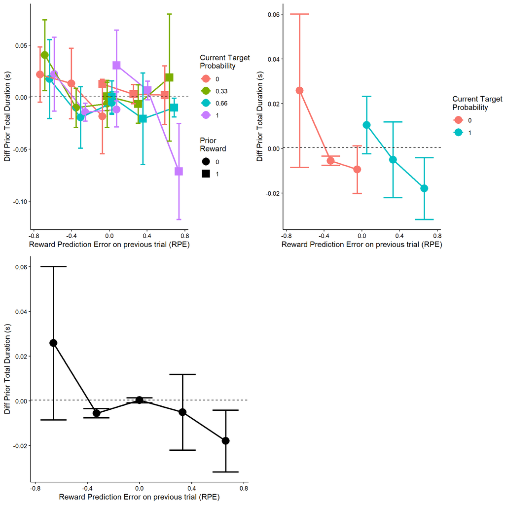

#### 7.4.0.1 T-Tests

Table 7.10: Paired t-test post hoc comparisons with Holm-Bonferonni correction for Total Duration Diff Prior (m/s).

|  | -1/3 | 0 | 1/3 | 2/3 |
| --- | --- | --- | --- | --- |
| -2/3 | 1 | 1 | 1 | 1 |
| -1/3 | NA | 1 | 1 | 1 |
| 0 | NA | NA | 1 | 1 |
| 1/3 | NA | NA | NA | 1 |

These are the uncorrected paired t-test values

Table 7.11: Paired t-test, no correction, for Total Duration Diff Prior (m/s).

|  | -1/3 | 0 | 1/3 | 2/3 |
| --- | --- | --- | --- | --- |
| -2/3 | 0.395 | 0.447 | 0.537 | 0.269 |
| -1/3 | NA | 0.114 | 0.976 | 0.433 |
| 0 | NA | NA | 0.749 | 0.257 |
| 1/3 | NA | NA | NA | 0.57 |

#### 7.4.0.2 Summary Table RPE

Table 7.12: Summary data table for Diff Prior Total Duration. Each row is a probability metric. This is compute subject average for each probability, then average the average. Data is shown as mean ± standard error (lower bound, upper bound) for the 95% confidence interval of that mean.

|  | Mean ± SE (lb, ub) |
| --- | --- |
| -0.66 | 0.0258 ± 0.0149 (-0.00339, 0.055) |
| -0.33 | -0.00554 ± -0.0032 (0.000729, -0.0118) |
| 0 | 0.000295 ± 0.00017 (-3.88e-05, 0.000628) |
| 0.33 | -0.0051 ± -0.00294 (0.000671, -0.0109) |
| 0.66 | -0.0179 ± -0.0103 (0.00236, -0.0382) |

# 8 Vigor

## 8.1 Effect of Probability

```
## boundary (singular) fit: see ?isSingular
## boundary (singular) fit: see ?isSingular
```

The equation below shows the linear model used:
$$Outcome \sim Probability + (1|Subject)$$

|  | P-Value | Slope | Intercept |
| --- | --- | --- | --- |
| All Target LMER | 7.342e-01 | -3.004e-03 ± 8.848e-03 | 6.352e-01 |
| Target 1/4 LMER | 8.567e-01 | -1.539e-03 ± 8.523e-03 | 6.338e-01 |
| Target 1/4 ANOVA | 9.894e-01 | F val: 2.003e-04 |  |

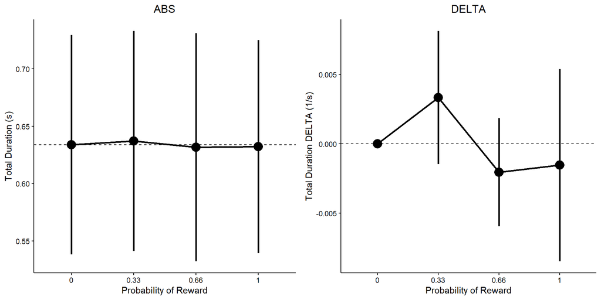

Table 8.2: Paired t-test post hoc comparisons with Holm-Bonferonni correction for Total Duration.

|  | 1/3 | 2/3 | 1 |
| --- | --- | --- | --- |
| 0 | 1 | 1 | 1 |
| 1/3 | NA | 1 | 1 |
| 2/3 | NA | NA | 1 |

These are the uncorrected paired t-test values

Table 8.3: Paired t-test, no correction, for Total Duration.

|  | 1/3 | 2/3 | 1 |
| --- | --- | --- | --- |
| 0 | 0.484 | 0.586 | 0.811 |
| 1/3 | NA | 0.368 | 0.222 |
| 2/3 | NA | NA | 0.95 |

#### 8.1.0.1 Summary Tables

Table 8.4: Summary data table for Total Duration. Each row is a probability metric. This is compute subject average for each probability, then average the average. Data is shown as mean ± standard error (lower bound, upper bound) for the 95% confidence interval of that mean.

|  | Mean ± SE (lb, ub) |
| --- | --- |
| 0 | 0.634 ± 0.366 (-0.0834, 1.35) |
| 0.33 | 0.637 ± 0.368 (-0.0838, 1.36) |
| 0.66 | 0.632 ± 0.365 (-0.0831, 1.35) |
| 1 | 0.632 ± 0.365 (-0.0832, 1.35) |

#### 8.1.0.2 Comparison of 0% and 100% Reward

In a paired t test of subject averages, there WAS NOT a significant difference between 0% and 100% reward conditions for Total Duration (p = 8.112e-01). .

In a ANOVA test of subject averages, there WAS NOT a significant difference between 0% and 100% reward conditions for Total Duration (p = 9.894e-01). .

## 8.2 Effect of Trial

The linear model used to predict effect of trial is shown below:
$$Outcome \sim B*Trial + (1|Subject)$$

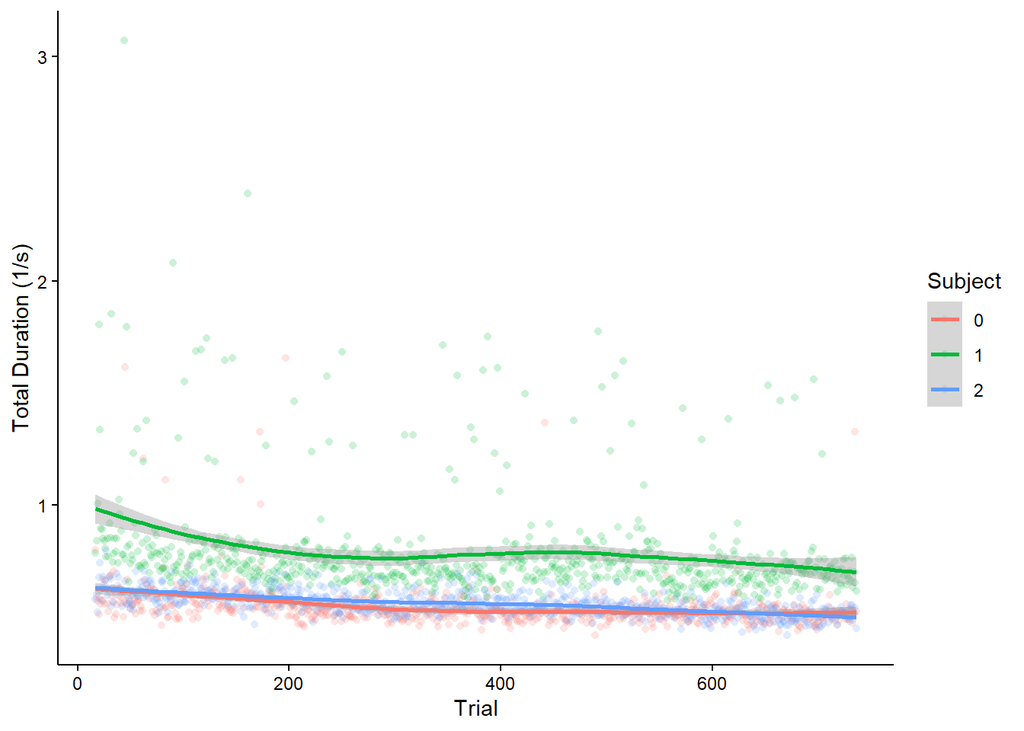

## 8.3 Vigor Following Reward

Using an ANOVA test, across subjects, the Total Duration in trials following rewarded trials WAS NOT statistically different than trials following nonrewarded tirlas (p = 9.761e-01)

Table 8.5: Total Duration P-Values for effect of Probability

|  | P-Value |
| --- | --- |
| T-test | 2.266e-01 |
| T-Test Prior==1 | 1.517e-02 |
| T-Test Prior==0 | 1.465e-02 |

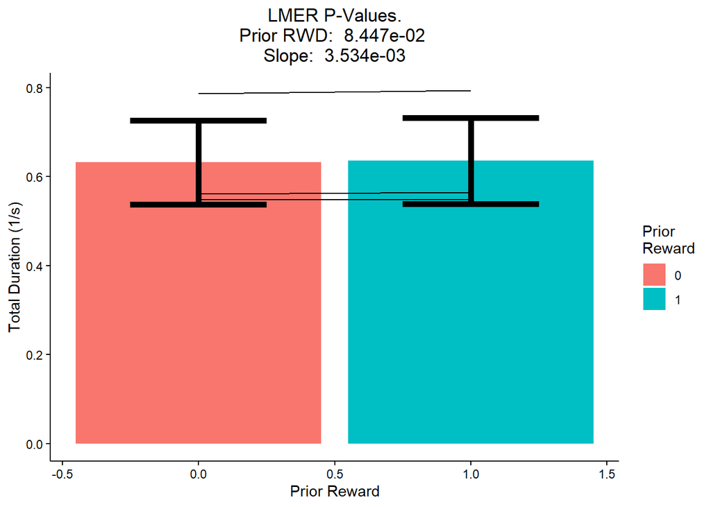

[output not shown]

In an interacation LMER of probability of reward and prior reward with subject as a random intercept effect, Total Duration WAS NOT affected by probability of reward (p = 1.908e-01) and WAS NOT affected by prior reward (p = 3.679e-01). An interaction of the two factors DID NOT affect Total Duration (p = 1.281e-01)

Dividing the data set into two groups (trials following reward and trials not following reward) resulted in finding NO significant slope of probability (p = 3.857e-01) in trials that follow reward, but finding NO significant slope (p = 2.025e-01) in trials that do not follow reward.

The linear model used to predict the effect of probability and prior reward is:

$$Outcome \sim Probability + Prior Reward + Probability*Prior Reward + (1|Subject)$$

|  | P-Value | Slope |
| --- | --- | --- |
| Intercept | 4.441e-16 | 6.402e-01 ± 7.863e-02 |
| Prob Metric | 1.908e-01 | -1.634e-02 ± 1.249e-02 |
| Prior RWD | 3.679e-01 | -9.903e-03 ± 1.100e-02 |
| Interaction | 1.281e-01 | 2.694e-02 ± 1.770e-02 |
| Lm Prior == 1 Prob Effect | 3.857e-01 | 1.061e-02 ± 1.223e-02 |
| LM Prior == 0 Prob Effect | 2.025e-01 | -1.631e-02 ± 1.280e-02 |

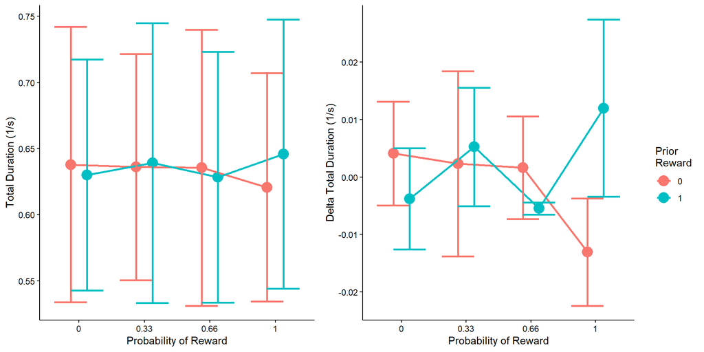

Table 8.7: TotalDur Diff Prior P-Values for effect of Probability

|  | P-Value |
| --- | --- |
| T-test | 5.613e-01 |
| T-Test Prior==1 | 8.752e-01 |
| T-Test Prior==0 | 2.597e-01 |

To further examine this effect of prior reward on Total Duration, the change in Total Duration was determined from trial to trial. In the above graph Delta Total Duration is the difference in Total Duration of the current trial minus the previous trial (PV_(trial=n)-PV_(trial=n-1)). There WAS NOT a statistical difference between trials following and not following reward (paired t-test of subject averages, p = 5.613e-01). Total Duration WAS NOT significantly different following reward (t-test of subject averages vs a mean of 0, p = 8.752e-01) and Total Duration DID NOT significantly different following trials where they were not rewarded (t-test of subject averages vs a mean of 0, p = 2.597e-01).

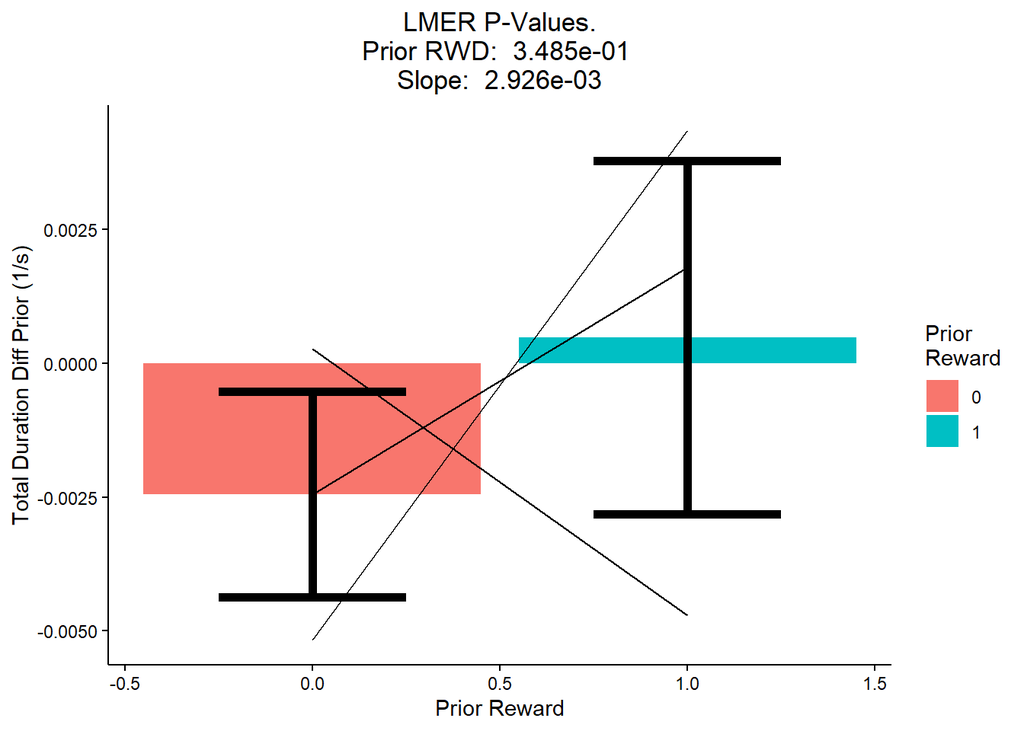

### 8.3.2 Interaction of Prior Reward and Change in Probability of Reward

Table 8.8: TotalDur Diff Prior P-Values for effect of Diff Probability

|  | P-Value | Slope |
| --- | --- | --- |
| Intercept | 6.868e-01 | 2.974e-03 ± 7.376e-03 |
| Prob Metric | 1.623e-01 | -1.930e-02 ± 1.381e-02 |
| Prior RWD | 4.914e-01 | -7.216e-03 ± 1.049e-02 |
| Interaction | 8.949e-01 | 2.602e-03 ± 1.969e-02 |
| Lm Prior == 1 Prob Effect | 2.420e-01 | -1.669e-02 ± 1.427e-02 |
| LM Prior == 0 Prob Effect | 1.555e-01 | -1.930e-02 ± 1.359e-02 |

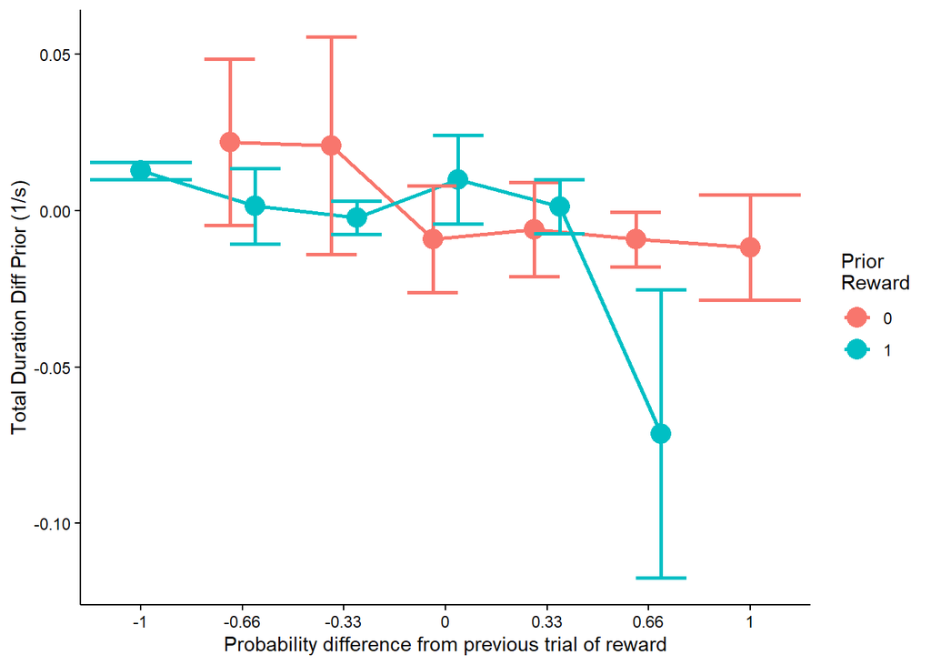

## 8.4 RPE

The linear model used to predict the effect of RPE and prior reward is:

$$Outcome \sim Probability + Prior Reward + Probability*Prior Reward + (1|Subject)$$

Dividing the data set into two groups (trials following reward and trials not following reward) resulted in finding NO significant slope of RPE (p = 9.328e-02) in trials that follow reward, but finding NO significant slope (p = 7.506e-02) in trials that do not follow reward.

Table 8.9: Vigor P-Values for effect of RPE

|  | P-Value | Slope |
| --- | --- | --- |
| Intercept | 1.461e-01 | -1.216e-02 ± 8.364e-03 |
| Prob Metric | 7.989e-02 | -4.468e-02 ± 2.551e-02 |
| Prior RWD | 6.147e-02 | 2.227e-02 ± 1.191e-02 |
| Interaction | 9.799e-01 | 9.128e-04 ± 3.618e-02 |
| Lm Prior == 1 Prob Effect | 9.328e-02 | -4.376e-02 ± 2.607e-02 |
| LM Prior == 0 Prob Effect | 7.506e-02 | -4.468e-02 ± 2.510e-02 |

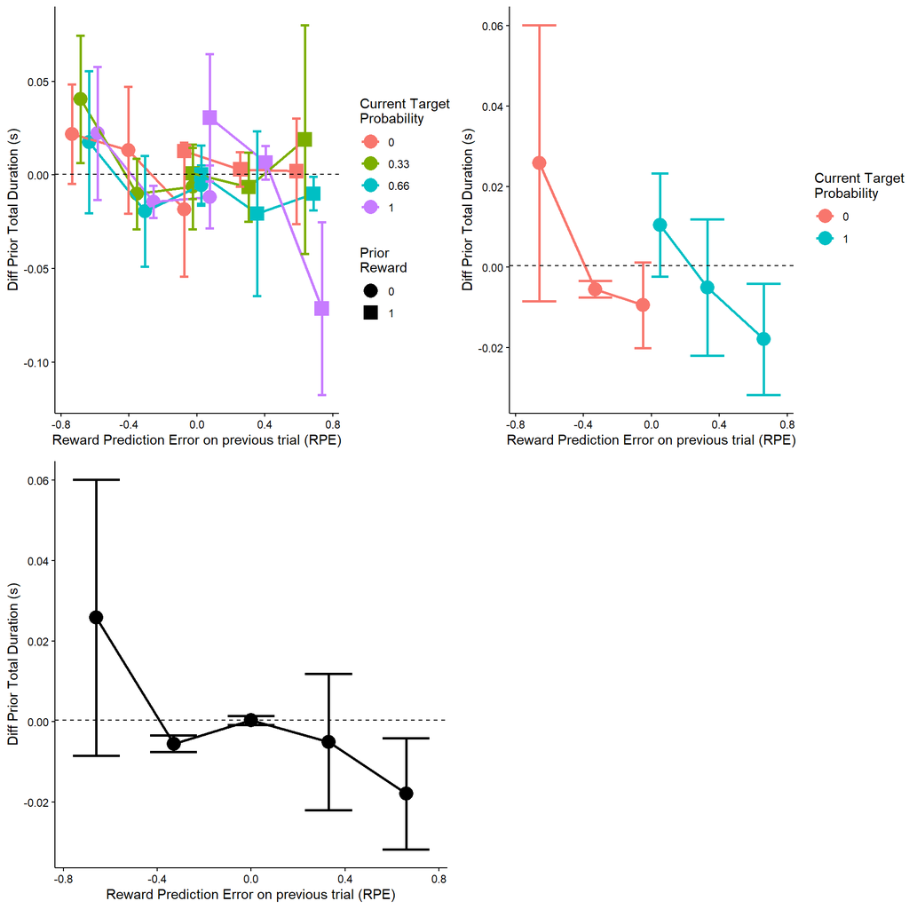

#### 8.4.0.1 T-Tests

Table 8.10: Paired t-test post hoc comparisons with Holm-Bonferonni correction for Total Duration Diff Prior (m/s).

|  | -1/3 | 0 | 1/3 | 2/3 |
| --- | --- | --- | --- | --- |
| -2/3 | 1 | 1 | 1 | 1 |
| -1/3 | NA | 1 | 1 | 1 |
| 0 | NA | NA | 1 | 1 |
| 1/3 | NA | NA | NA | 1 |

These are the uncorrected paired t-test values

Table 8.11: Paired t-test, no correction, for Total Duration Diff Prior (m/s).

|  | -1/3 | 0 | 1/3 | 2/3 |
| --- | --- | --- | --- | --- |
| -2/3 | 0.395 | 0.447 | 0.537 | 0.269 |
| -1/3 | NA | 0.114 | 0.976 | 0.433 |
| 0 | NA | NA | 0.749 | 0.257 |
| 1/3 | NA | NA | NA | 0.57 |

#### 8.4.0.2 Summary Table RPE

Table 8.12: Summary data table for Diff Prior Total Duration. Each row is a probability metric. This is compute subject average for each probability, then average the average. Data is shown as mean ± standard error (lower bound, upper bound) for the 95% confidence interval of that mean.

|  | Mean ± SE (lb, ub) |
| --- | --- |
| -0.66 | 0.0258 ± 0.0149 (-0.00339, 0.055) |
| -0.33 | -0.00554 ± -0.0032 (0.000729, -0.0118) |
| 0 | 0.000295 ± 0.00017 (-3.88e-05, 0.000628) |
| 0.33 | -0.0051 ± -0.00294 (0.000671, -0.0109) |
| 0.66 | -0.0179 ± -0.0103 (0.00236, -0.0382) |